# Chapter 9: Solving Differential Equations

**Goals**

## 9.1 Differential Equations and Coffee

### 9.1.1 A General Introduction

> *In the 300 years since Newton, mankind has come to realize that the laws of physics are always expressed in the language of differential equations.*

> Steven Strogatz, [New York Times](https://archive.nytimes.com/opinionator.blogs.nytimes.com/2009/05/26/guest-column-loves-me-loves-me-not-do-the-math/)

It is often easier to describe how something **changes** than to know its **particular state** at any given moment in time. This is why differential equations are found in so many areas of physics and are of central importance to engineers. I highly recommend watching this [video (series)](https://youtu.be/p_di4Zn4wz4?si=llw6w_zOTOj2E0_U) by *3Blue1Brown* on Youtube! Differential equations are by no means dull and boring (... well sometimes). In contrast, they produce some of the most beautiful behavior you can imagine, because they describe the laws of nature and nature itself is beautiful.

[figure not shown]

### 9.1.2 Basic Coffee Extraction Kinetic

When coffee beans are ground and suspended in hot water, a variety of (partly) delicious chemicals are released into the water phase. The mass transfer of caffeine from the coffee particle into the water phase can be approximated by the following **ordinary differential equation** (ODE) or process kinetic [[Spiro1984](https://doi.org/10.1002/jsfa.2740350817)]:

$$ \frac{\mathrm{d}c}{\mathrm{d}t}=\underbrace{k(c_{\infty}-c)}_{\mathrm{rhs}} \quad \quad \quad (1)$$

The extraction is limited by $c_{\infty}$ which visually describes the maximum caffeine concentration in water (solubility) and its speed is described by the kinetic parameter $k$. Both values depend on a variety of process and material specific parameters, as e.g. coffee grind size and water temperature. We will focus more on these parameters in the next chapter.

Remembering some of your long-forgotten mathematical skills, you hopefully see that this ODE can be solved rather easily *by hand*. The so-called *analytical* solution

$$ c(t) = c_{\infty}-(c_{\infty}-c_0)exp(-kt)) $$

will serve as reference point to evaluate the accuracy of our numerical solution. $c_0$ is the initial concentration at $t=0$. Does thing ring any bells with respect to last week's homework (sorry, I have to.. )?

> ***Note:*** In many physical problems an analytical solution is not available! One example are the [Navier-Stokes equations](https://en.wikipedia.org/wiki/Navier%E2%80%93Stokes_equations) describing fluid flow. Therefore it is important to learn about *numerical* solution strategies.

## 9.2 The Forward Euler Method

The forward Euler method is probably the easiest way to solve an ODE numerically, i.e. to obtain $c(t)$. Eq. 1 gives you the derivative at any given point. All you have to do is evaluate the **right hand side** (rhs) of the equation. Unfortunately, the derivative alone will never be enough to define where the final functional relationship lies. For example, consider several straight lines with identical slopes but different offsets (parallels): Their derivatives are identical at each point, but their functional values are obviously not. Therefore, you need a starting point or **initial value** to solve for $c(t)$. We call this an initial value problem.

The actual forward Euler algorithm is then given by the following steps:

1. Evaluate the right hand side (rhs, Eq. 1) for the initial value $(c_0,t_0)$. This yields $\left(\frac{\mathrm{d}c}{\mathrm{d}t}\right)_{0}$.
2. Assume that $c(t)$ grows *linearly* if you just zoom in close enough. Therefore, when we take a step $\Delta t$ in time, we can approximate the new concentration at time $t_1=t_0 + \Delta t$ by evaluating the **tangent**:

$$c_1=c(t_0+\Delta t) = c_0 + \Delta t \cdot \left(\frac{\mathrm{d}c}{\mathrm{d}t}\right)_{0}$$

3) Since we now know the new value pair $(c_1, t_1)$, we can repeat this process until we reach a desired $t_{end}$. In general, we can write $$c_{i+1} = c_i + \Delta t \cdot \left(\frac{\mathrm{d}c}{\mathrm{d}t}\right)_{i}$$

Keep in mind that this is only an **estimate** of the true (analytical) solution. The accuracy is massively affected by the value of the step size $\Delta t$. This makes sense, since the assumption of linear growth becomes more accurate the closer you **"zoom in"**. Also note that you will only get values for $c(t)$ on a discrete time grid, which can be defined in `numpy` terms by `t_disc=np.arange(t_0,t_end,del_t)`. The algorithm and the effect of the step size are visualized in the animated Figure 1.

[figure not shown]

**Figure 1:** *Visualization of the forward Euler method for $\Delta t=500s$ (left) and $\Delta t=100s$ (right).*

Let's put this into practice and calculate the caffeine extraction kinetic numerically for a given pair of parameters $(k, c_{\infty})=(1\times 10^{-3}, 5\times 10^{-4})$ and the initial point $(c_0, t_0)=(0, 0)$. The step size is defined by `del_t` and the final extraction time is defined by `t_end`. Feel free to play around with those values! We will compare the numerical with the analytical solution, but remember: In most cases you don't know the *"true"* solution!

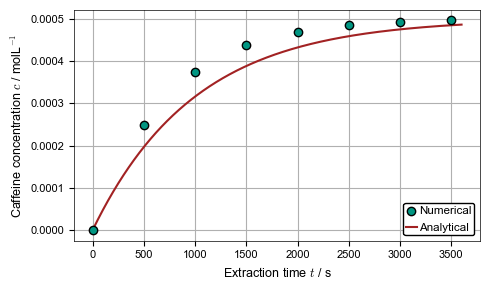

```python
import numpy as np
import matplotlib.pyplot as plt
import mod.my_plotter as mp
mp.init_plot(scl_a4=1, page_lnewdth_cm=10)

# Parameter definitions
c_0 = 0                             # Initial concentration
t_0 = 0                             # Initial time

c_inf = 5e-4                        # Solubility of caffeine [mol/L]
k = 1e-3                            # Kinetic parameter [1/s]

del_t = 500                         # Time-step [s]
t_end = 3600                        # Extraction time [s]

# Set up time and concentration array
t = np.arange(t_0,t_end,del_t)      # Start at t_0 and go with del_t steps until t_end is reached
c = np.zeros(t.shape)               # Create an array of identical shape and initialize with 0
c[0] = c_0                          # Initialize the start concentration

# Calculate the analytical solution (for visualization)
t_a = np.linspace(t_0, t_end, 1000)
c_a = c_inf-(c_inf-c_0)*np.exp(-k*t_a)

# Actual forward Euler loop
for i in range(len(t)-1):
    dcdt = k*(c_inf-c[i])           # Current slope (rhs)
    c[i+1] = c[i] + del_t*dcdt      # New concentration

# Plot results and make pretty
fig, ax = plt.subplots(figsize=(5,3))

# Only plot every n-th datapoint to make it less crowded
n = 1
ax.scatter(t[0::n], c[0::n], edgecolors='black', color=mp.green, zorder=3, label='Numerical')
ax.plot(t_a, c_a, color=mp.red, zorder=2, label='Analytical')

ax.set_xlabel('Extraction time $t$ / s')
ax.set_ylabel('Caffeine concentration $c$ / molL$^{-1}$')
ax.legend(loc='lower right', fontsize='small', framealpha=1, ncol=1, labelspacing = 0.6)
ax.grid(True)
plt.tight_layout()
```

## 9.3 Solving the ODE with `scipy.integrate.solve_ivp()`

The forward Euler method is very intuitive and easy to code, but it has some major limitations:

1. A static time-step can lead to either inaccurate or unstable calculations (if chosen too large) or might cause unnecessarily long calculation times (if chosen too small). Roughly speaking, the **correct** choice of the time step depends on the current slope $\frac{\mathrm{d}c}{\mathrm{d}t}$ and should therefore be adjusted *dynamically*.
2. Without going into further detail, the numerical errors (inaccuracies) are rather high due to the simple discretization scheme.

There are a variety of numerical schemes for solving ODEs in a more sophisticated way. Methods of the *Runge-Kutta* family extend the forward Euler scheme by focussing not only on the current slope, but also on the slope at various other points of time. This results in a set of linear equations that can be solved for the subsequent time step. In short, these methods improve numerical accuracy, but require a bit more mathematical effort. Furthermore, an *adaptive time step* can be implemented to alleviate the above mentioned problems.

Luckily, a lot of clever people have already worked together and programmed various numerical methods for solving initial value ODE problems. Today, we will use the `solve_ivp( )` method of the `scipy.integrate` library, but note that there are other projects and libraries out there! A look at the [documentation](https://docs.scipy.org/doc/scipy/reference/generated/scipy.integrate.solve_ivp.html#scipy.integrate.solve_ivp) reveals how the method works. The most important *parameters* and *returns* are listed below:

**Parameters:**

- `fun` (*required*): Right hand side function of the ODE. The calling signature is `fun(t,y)`. This means that the function **must** take `t` (scalar) and `y` (1D-array) as inputs **in this order**. Similar to the cost function of chapter 6, we have to define this rhs-function in our script.
- `t_span` (*required*): Interval of integration as `tuple`, i.e. `(t_0, t_end)`.
- `y0` (*required*): Initial value(s) of `y`.
- `method` (*optional*): The actual solver to use. The default is `'RK45'`, referring to the explicit Runge-Kutta method of order 5(4) (don't worry too much about it for now).
- `t_eval` (*optional*): Array with times at which the numerical solution should be *stored* and returned. Does not affect the accuracy of the solution!
- `args` (*optional*): Additional arguments that can be passed to `fun`. We will see this in the example below.

**Returns:**

The method returns an object containing the actual information. It's most important attributes are:

- `t`: The (discrete) time points of the solution.
- `y`: Corresponding values of the solution at times `t`.

> ***Note:*** `solve_ivp()` is able to solve a **system of ODEs**, i.e. multiple equations with multiple target variables $y_1, y_2, ...$. In our case, we only have one ($c$), but because of the way the method is programmed, we still have to pass `y0` as a 1D-array. It's shape is simply `(1,)`.

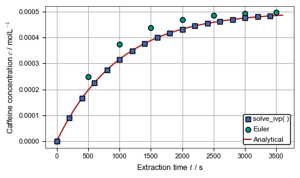

```python
from scipy.integrate import solve_ivp

# Define the right hand side function
## Note 1: As stated in the documentation, the first two arguments (in this order) have to be t and y
## Note 2: We need additional arguments k and c_inf, which we will pass later. Again, the order is important as we will see in a bit
## Note 3: y is required to be an array, here of shape (1,). The return value has to be of the same shape!
def rhs_kinetic(t, y, k, c_inf):
    dydt = k*(c_inf-y)
    return dydt

# Parameter definitions
save_interval = 200                   # Save interval [s]

# Set up time array for saving the numerical results
t_save = np.arange(t_0,t_end,save_interval)   # Start at t_0 go with save_interval steps until t_end is reached

# Solve the ODE
# Note: All arguments other than t and y have to be passed via the args keyword
solution = solve_ivp(fun=rhs_kinetic, t_span=(t_0,t_end), y0=np.array([c_0,]),
                     method='RK45', t_eval=t_save, args=(k, c_inf))

# Extract t_num and c_num from the solution object
t_num = solution.t
c_num = solution.y

# Plot results and make pretty
fig, ax = plt.subplots(figsize=(5,3))

ax.scatter(t_num, c_num, edgecolors='black', marker='s', color=mp.blue, zorder=4, label='solve_ivp( )')
ax.scatter(t[0::n], c[0::n], edgecolors='black', color=mp.green, zorder=3, label='Euler')
ax.plot(t_a, c_a, color=mp.red, zorder=2, label='Analytical')

ax.set_xlabel('Extraction time $t$ / s')
ax.set_ylabel('Caffeine concentration $c$ / molL$^{-1}$')
ax.legend(loc='lower right', fontsize='small', framealpha=1, ncol=1, labelspacing = 0.6)
ax.grid(True)
plt.tight_layout()
```

Let's see how both methods compare on a more *"unsteady"* example with corresponding analytical solution:

$$ \frac{\mathrm{d}y}{\mathrm{d}\varphi}=\mathrm{cos}(\varphi) \quad \rightarrow \quad y(\varphi)=\mathrm{sin}(\varphi)$$

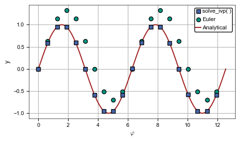

```python
# Define right hand side function
def rhs_cos(t, y):
    return np.cos(t)

# Set up step-size del_phi, phi and y array
del_phi = np.pi*0.2
phi = np.arange(0,4*np.pi,del_phi)
y = np.zeros(phi.shape)

# Calculate analytical solution
phi_a = np.linspace(0,4*np.pi,1000)
y_a = np.sin(phi_a)

# Calculate forward euler
for i in range(len(phi)-1):
    dydphi = rhs_cos(phi[i],42)       # Use the rhs_cos function defined above. It does not matter what we give as input for y
    y[i+1] = y[i] + del_phi*dydphi

# Calculate solve_ivp
solution = solve_ivp(fun=rhs_cos, t_span=(phi[0],phi[-1]), y0=np.array([phi[0],]),
                     method='RK45', t_eval=phi)

# Plot results and make pretty
fig, ax = plt.subplots(figsize=(5,3))

ax.scatter(solution.t, solution.y, edgecolors='black', marker='s', color=mp.blue, zorder=4, label='solve_ivp( )')
ax.scatter(phi, y, edgecolors='black', color=mp.green, zorder=3, label='Euler')
ax.plot(phi_a, y_a, color=mp.red, zorder=2, label='Analytical')

ax.set_xlabel(r'$\varphi$')
ax.set_ylabel('y')
ax.legend(loc='upper right', fontsize='small', framealpha=1, ncol=1, labelspacing = 0.6)
ax.grid(True)
plt.tight_layout()
```

As you can see, the forward Euler *"overshoots"* the maxima, and differs significantly from the analytical solution. See what happens when you play around with the step size $\Delta \varphi$. `solve_ivp( )` takes care of the step size for you and does this quite efficiently.

## 9.4 Final Notes

The numerical solution of differential equations is a vast field. We have barely scratched the surface here, but the core concept remains the same throughout: Estimate the future evolution of a function by evaluating the current slope.

The Master course *Computational Fluid Dynamics* will cover this in much more detail!